# Vizualizing the data

## Policies and Cases

Since our main goal is to see if media coverage differs in countries with different reactions to the pandemic, the first step is to analyse whether Swedish and German reactions and case numbers actually differ.

First off we want to show how the situations of new confirmed cases and the corresponding policies differ between the two countries. This is to see, whether the countries’ responses do differ as is communicated in German media.

```r
limits <-  as.Date(c('2020-01-01', '2020-12-31'))
# read the timeline data from the csv-file
timeline_data <- read.csv('./../data/timeline_data.csv') %>%
  mutate(start = as.Date(start, format = "%Y-%m-%d"),
         end = as.Date(end, format = "%Y-%m-%d"))
# determine range of events
event_range <- timeline_data %>% select(event) %>% range()
# build color map depending on the range of events
color_map <- rev(viridis(event_range[2]+1))
# add column color and event for specific policy and corresponding policy
timeline_data %<>% mutate(color = color_map[as.integer(event)+4]) %>%
                   mutate(event = as.character(event))
# build time line plot for the Restriction of gatherings policy
time_line_plot <- ggplot(timeline_data, aes(x=start, xend=end, y=group, yend=group, color=event)) +
  geom_segment(size=10,) +
  scale_color_manual(labels=c('no restrictions', 'above 1000 people','101-1000 people', '11-100 people', '10 people or less'), values = color_map) +
  labs(x = 'Date', y = 'Country',
       colour="Restrictions on\n gatherings") +
  scale_x_date(limits = limits)
```

After having the policy time line for Germany and Sweden the time-series for the normalized new cases gets added:

```r
# read the time-series data from the csv-file
timeseries_data <- read.csv('./../data/timeseries_data.csv') %>%
  mutate(date = as.Date(date, format = "%Y-%m-%d")) # change data type to date
# define colors for time series plot
COLORS <- c(Germany = "steelblue", Sweden ="darkred")
# build time-series plot
lineplot <- timeseries_data %>% ggplot(aes(x = date, y = new_cases_smoothed_per_million,
                   group = location, color = location)) +
  geom_line() +
  scale_color_manual(values = COLORS) +
  labs(x = '', y = 'Smoothed New Cases\n per\n Million',
       colour="Countries",
       title = "Time Series of New Cases and Restrictions on Gatherings") +
  scale_x_date(limits = limits)+
  theme(plot.title = element_text(hjust = 0.5,face = 'bold'))
```

We plot the data as subplots by the cowplot library:

[figure not shown]

Time-series of smoothed new cases and restrictions on gatherings.

```r
plot_grid(lineplot, time_line_plot,
          ncol = 1, align='v')
```

After cleaning the data and building the plot, we retrieve a subplot consisting of a time series of the smoothed new cases per million of COVID-19 for Germany and Sweden. As a comparison, we plotted the corresponding policies Germany and Sweden released in respect to restrictions on gatherings.

That said we want to go into how situations in Germany and Sweden changed and how the countries reacted to those. Especially of interest was the time before the pandemic peak in Germany in April. Both countries started on restricting gatherings. Germany reduced the allowed gatherings of 1000 people, while Sweden was restricting it to 101-1000 people. After approximately a week Germany went into a lockdown, while Sweden reduced the number of allowed people in a gathering to 11-100. This policy was kept by the Swedish Government until recently. While the German federal governments tried to lighten the policies during late summer, those attempts have been overthrown with the increasing number of new cases though.

This shows that Sweden chose way lighter policies with respect to gatherings than Germany even with a way higher number of new confirmed cases.

So that we were asking ourself how this affected the narrative of the two countries to each other. The idea was to compare the news reports of the countries over each other.

## Amount of reports

Since the crisis-response seems to be different and we got the impression of the use of Sweden as a bad example in German media, we wanted to see, whether the reporting in both countries about the respective other differed as well. The first aspect we found interesting, was the amount of articles over time.

Since we expect a coupling of case numbers and number of articles, we’ll try to compare those. To make the comparison easier, we’ll scale all values so that the relative maximum in the time frame is set to 100%. Due to rate limiting, we do only have article counts until the end of November.

[figure not shown]

```r
sentiment_time_series <-
  read_rds('./../data/documents_with_sentiments.rds') %>% # import data
  mutate(publish_date = lubridate::as_date(as.Date(publish_date))) %>% # fix dates
  group_by(country, publish_date) %>%
  summarise('number of articles' = n()) %>% # summarise data
  ungroup() %>%
  group_by(country) %>%
  group_split() %>%
  map(~mutate(., across(where(is.numeric), ~ 100 * . / max(.)))) %>% # scale all data to a max of 100%
  map_dfr( ~ mutate(., across(
    where(is.numeric),
    ~ stats::filter(., filter = dnorm(seq(-2, 2, length.out = 7)) /
                      sum(dnorm(
                        seq(-2, 2, length.out = 7)
                      ))),
    .names = 'filter_{.col}'
  ))) %>% # add a column with gaussian low-pass filtered data
  rename('original_number of articles' = 'number of articles') %>% # nicer names
  pivot_longer(
    cols = where(is.numeric),
    values_to = 'value',
    names_to = c('quality', 'indicator'),
    names_sep = '_'
  ) %>%
  pivot_wider(names_from = quality,
              values_from = value) # rejig to have a nicer format for the plot

timeseries_data %<>%
  group_by(location) %>%
  group_split() %>%
  map_dfr(~mutate(., cases = 100 * new_cases_smoothed_per_million/max(new_cases_smoothed_per_million))) # scale incidence data to a max of 100%


article_timeseries_viz <-
  sentiment_time_series %>%
  mutate(country = recode(country,
                          Germany = 'German news \n about Sweden',
                          Sweden = 'Swedish news \n about Germany')) %>% # nicer facet-names
  ggplot(aes(x = publish_date, y = original)) +
  geom_point(color = scales::muted('blue'), alpha = .1) + # add the article counts per day
  geom_line(aes(y = filter), color = scales::muted('blue')) + # add the smoothed article counts
  facet_grid(rows = vars(country),scales = 'fixed') + # display in facets
  geom_line(data = timeseries_data, aes(y = cases, x = date, color = location)) + # add incidence
  scale_color_manual(values = COLORS) + # use colors from earlier
  theme(legend.position = 'bottom', # legend to bottom
        plot.title = element_text(hjust = 0.5,face = 'bold')) +
  labs(x = 'Date of Publication',  # nicer axis and plot title
       y = 'New cases and articles in % of Maximum',
       color = 'New Covid-19 cases:',
       title = 'News articles and new cases in Sweden and Germany') +
  scale_x_date(limits = as.Date(c('2020-01-01', '2020-11-20'))) # limit dates
article_timeseries_viz
```

By comparing these time-series with the infection-rates, one can recognize signs of a similarity in the number of German mentions of Sweden and Corona and the amount of cases in Sweden. Since the amount of articles seems to loosely be coupled to the amount of cases in the respective other country, we will look at the content of these reports. It seems interesting, whether these reports are purely factual, or if some emotional loading can be detected.

## Sentiments

Let’s start by using the rather patchy sentiments we were able to gather to generate a few maps of the regions of both countries depicting the respective tonality.

So let’s first load the data and the countries’ outlines:

```r
sf_data <- get_eurostat_geospatial(resolution = '10', # get the nice looking european geo data
                                   nuts = 3) %>%
  filter(CNTR_CODE %in% c('SE')) %>%
  bind_rows(get_eurostat_geospatial(resolution = '10',
                                    nuts = 1) %>%
              filter(CNTR_CODE %in% c('DE'))) %>%
  mutate(NAME_LATN = str_to_lower(NAME_LATN))

se_countrycodes <- read_tsv('https://www.iso.org/obp/ui/#iso:code:3166:SE') # get the country codes

regional_sents <- read_rds('./../data/documents_with_sentiments.rds') %>%
  group_by(country) %>%
  group_split() %>%
  map_dfr(~group_by(.,pub_state,country) %>%
            summarise(sentiment = mean(m_sentiment))) # get the sentiments per state
```

Now we need to cross-reference the Mediacloud countrycodes (ISO 3166:SE, ISO 3166:DE) with the `eurostat` ones:

```r
iso_3166 <- read_csv('./../data/regional_codes.csv') %>%  # add regional codes to make data sets joinable
  mutate(across(everything(), ~str_trim(.)))%>%
  mutate(Provinz = str_to_lower(Provinz))

regional_sents %<>%
  right_join(iso_3166, by = c(pub_state = 'Code')) # and join
```

This dataset can now be used to depict the overall regional sentiment in both countries:

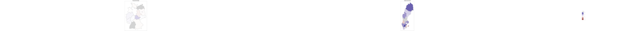

Mean sentiment per region as detected in the mainstream-news articles about the respective other country.

```r
reg_sent_plot <- function(data,legend, title = ''){ # function to plot regional sentiments
  p <- ggplot(data) +
    geom_sf(aes(geometry = geometry,fill = sentiment), color = 'grey', expand = F) +
    scale_fill_gradient2(low = scales::muted('red'),
                         mid = 'white',
                         high = scales::muted('blue'),
                         na.value = 'lightgrey',
                         limits = c(-5,5))   +
    theme_void()
    if(!legend){
      p <- p + theme(legend.position = 'none')
    }else{
      p <- p + theme_void() + theme(legend.position = 'right')
    }
  p +
    coord_sf(crs = st_crs("+proj=merc")) +
    labs(title = title) +
    theme(plot.title = element_text(hjust = 0.5,face = 'bold'),
          panel.border = element_rect(color = 'lightgrey',
                                      size = 1,
                                      fill = NA))
}

plots <- sf_data %>%
  left_join(regional_sents[,c('Provinz', 'sentiment')],by = c('NAME_LATN' = 'Provinz')) %>%
  group_by(CNTR_CODE) %>%
  group_split() %>% # split for two plots
  list(df = ., titles = c('Germany about Sweden', 'Sweden about Germany')) %>%  # change to nested list for pmap
  pmap(~reg_sent_plot(..1,legend = F,title = ..2)) # build list of plots

legend <- cowplot::get_legend(reg_sent_plot(mutate(sf_data,sentiment = 0),legend = T)) # generate legend

cowplot::plot_grid(
  cowplot::plot_grid(plotlist = plots),
  legend,
  rel_widths =  c(4,.6)
)
```

Since the resulting sentiments are really unexpected, we’ll try a qualitative approach. We decided to create some wordclouds to get a better impression of the reports’ tonality.

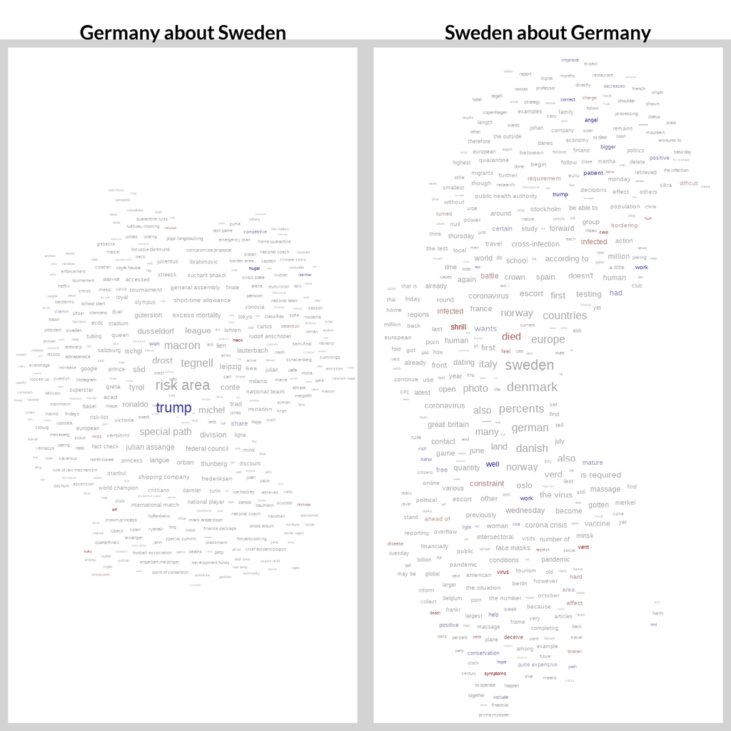

```r
wc_data <- read_rds('./../data/wordcloud_data.rds')
wordcloud <- function(wc_data,country, title){
  require(ggwordcloud)
  # generate temp. masks for wordclouds
  p <- get_eurostat_geospatial(resolution = '10',
                                   nuts = 0) %>%
    filter(CNTR_CODE %in% c(country)) %>%
    ggplot() +
    geom_sf(fill = 'black', color = 'black') +
    coord_sf(crs = st_crs("+proj=moll")) +
    theme_void()

  ggsave('temp.png', plot = p)

  img <- png::readPNG('temp.png')

  dummy <- colSums(img[,,1]) != max(colSums(img[,,1]))
  img <- img[,dummy,]
  dummy <- rowSums(img[,,1]) != max(rowSums(img[,,1]))
  img <- img[dummy,,] # cut the image to size

  wc <- ggplot(wc_data,aes(label = translation, size = n, color = sentiment)) +
    geom_text_wordcloud(mask = img,rm_outside = T)+
    scale_color_gradient2(low = scales::muted('red'),
                         mid = 'grey',
                         high = scales::muted('blue'),
                         na.value = 'darkgrey',
                         limits = c(-5,5)) +
    labs(title = title) +
    theme_void(base_family = 'lato', base_size = 20) +
    theme(plot.title = element_text(hjust = 0.5,face = 'bold'),
          panel.border = element_rect(color = 'lightgrey',
                                      size = 1,
                                      fill = NA)) # plot the image

  file.remove('temp.png') # remove the temp. mask

  wc
}

ger_wc <- wc_data %>%
  filter(country == 'Germany') %>%
  arrange(desc(n)) %>%
  head(750) %>%
  wordcloud(country = 'DE',
            title = 'Germany about Sweden')
swe_wc <- wc_data %>%
  filter(country == 'Sweden') %>%
  arrange(desc(n)) %>%
  head(750) %>%
  wordcloud(country = 'SE',
            title = 'Sweden about Germany')
p <- cowplot::plot_grid(ger_wc, swe_wc)

ggsave('./../imgs/wordclouds.png', p,width = 4, height = 4,units = 'in') # higher resolution
```

As we can see in the wordclouds, the most used words in German news articles about Sweden have been ‘risk area’, ‘trump’, ‘tegnell’, ‘macron’ and ‘special path’. Especially the terms ‘risk area’ and ‘special path’ are in the context of the Pandemic of interest. Although the articles seem to not all be exclusively about Sweden, ‘risk area’ and ‘special path’ are two distinct phrases that show the tonality of the reports about Sweden.

The Swedish news articles about Germany in contrary used ‘sweden’, ‘denmark’, ‘german’ and ‘europe’ the most, which shows that Germany was rather mentioned in a European context then on it’s own. Other words such as died, virus, infected, epidemic, disease, debt or hurt have been found in the wordclouds of Sweden news articles about Germany.

Most of the sentiments related to the pandemic have been detected such as died, virus, infected, epidemic, disease, debt or hurt. Unfortunately for some words the sentiment analysis hasn’t worked since a lot of the words used in the pandemic are of special vocabulary, such as risk area and special path. Furthermore the word Trump has been detected as the English word used for playing cards instead of the current president of the United States.